# BDA505_Group_Project

# New York Taxi Data Set

- ShineRs
- [Özge Beğde](https://www.linkedin.com/in/%C3%B6zge-be%C4%9Fde-569887aa/)
- [Mustafa Ömer Güçlü](https://www.linkedin.com/in/mustafa-%C3%B6mer-g%C3%BC%C3%A7l%C3%BC/)
- [Özgün Kurt](https://www.linkedin.com/in/mehmet-ozgun-kurt-bb0a867a/)
- [Sezer Ulutaş](https://www.linkedin.com/in/sezerulutas/)
- [Emir İnanç](https://www.linkedin.com/in/emir-abdulkadir-inanc-01ab7431/)

## Introduction

The NYC taxi dataset holds data of trips taken by taxis and for-hire vehicles in New York City. It can be reached at https://registry.opendata.aws/nyc-tlc-trip-records-pds/. The aim is to import a portion of taxi data ranging from 2018-01 to 2018-04 into a Amazon S3 Bucket, and then perform Exploratory Data Analysis. Firstly, functions to import the data into S3 bucket will be defined and explained. These functions were mostly inspired by the tutorial on provided on the dataset link: “Exploring data with Python and Amazon S3 Select”. The difference is that S3 select will not be relevant in the following steps.

[trips-2018-02.csv](https://drive.google.com/file/d/1AE3Qs3gW6CI1DIKZnge8fo6KnReF-lcl/view?usp=sharing)

## Part 0: Import dependencies

The modules below are necessary to run the components of this project. The examiner may need to install the boto3 package before attempting to import it. Since EDA will be done via R, R packages are needed as well.

```python
#python -m pip install boto3, if boto3 is not installed

import boto3
import io
import botocore
import pandas as pd
```

In order to access AWS S3 Bucket authentication is needed. The connection set-up is as follows

```python
ACCESS_KEY = "AKIAZ6FGTBKCHDYTL73P"
SECRET_KEY = "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"

s3 = boto3.client(
    's3',
    aws_access_key_id= ACCESS_KEY,
    aws_secret_access_key= SECRET_KEY
    )

s3_resource = boto3.resource(
    's3',
    aws_access_key_id= ACCESS_KEY,
    aws_secret_access_key= SECRET_KEY
    )
```

## Part 1: Import NYC Taxi Data to Amazon S3 Bucket

### Part 1.1: Functions to Perform the Import

First thing first: define the function to a create the bucket to receive the datasets

```python
def create_bucket(bucket):
    import logging

    try:
        s3.create_bucket(Bucket=bucket)
    except botocore.exceptions.ClientError as e:
        logging.error(e)
        return 'Bucket ' + bucket + ' could not be created.'
    return 'Created or already exists ' + bucket + ' bucket.'
```

Secondly, define a function to list existing buckets.

```python
def list_buckets(match=''):
    response = s3.list_buckets()
    if match:
        print(f'Existing buckets containing "{match}" string:')
    else:
        print('All existing buckets:')
    for bucket in response['Buckets']:
        if match:
            if match in bucket["Name"]:
                print(f'  {bucket["Name"]}')
```

The following two functions respectively check whether the item exists in a given bucket, and if it exists transfers item from the Amazon public dataset bucket to the bucket that will contain the datasets to be used for EDA.

```python
def key_exists(bucket, key):
    try:
        s3_resource.Object(bucket, key).load()
    except botocore.exceptions.ClientError as e:
        if e.response['Error']['Code'] == "404":
            return(False)
        else:

            raise
    else:
        # The key does exist.
        return(True)
```

```python
def copy_among_buckets(from_bucket, from_key, to_bucket, to_key):
    if not key_exists(to_bucket, to_key):
        s3_resource.meta.client.copy({'Bucket': from_bucket, 'Key': from_key},
                                        to_bucket, to_key)
        print(f'File {to_key} saved to S3 bucket {to_bucket}')
    else:
        print(f'File {to_key} already exists in S3 bucket {to_bucket}')
```

This function provides a preview for a selected dataset to confirm that transferred items have arrived safe and sound.`

```python
def preview_csv_dataset(bucket, key, rows=10):
    data_source = {
            'Bucket': bucket,
            'Key': key
        }
    url = s3.generate_presigned_url(
        ClientMethod = 'get_object',
        Params = data_source
    )

    data = pd.read_csv(url, nrows=rows)
    return data
```

### Part 1.2: Perform the Import

The data is imported in three steps: 1) create the destination bucket, 2) transfer items to the destination bucket, 3) confirm that destination bucjet exists.

```python
## create the destination bucket
create_bucket('bda-open-taxi-trip-data-analysis')

## transfer items
```

```
## 'Created or already exists bda-open-taxi-trip-data-analysis bucket.'
```

```python
for month in range(1,5):
    from_key = 'trip data/green_tripdata_2018-{0:0=2d}.csv'.format(month)
    to_key = 'few-trips/trips-2018-{0:0=2d}.csv'.format(month)
    copy_among_buckets(from_bucket='nyc-tlc', from_key=from_key,
    to_bucket='bda-open-taxi-trip-data-analysis', to_key=to_key)

## view the contents of the destination bucket
```

```
## File few-trips/trips-2018-01.csv already exists in S3 bucket bda-open-taxi-trip-data-analysis
## File few-trips/trips-2018-02.csv already exists in S3 bucket bda-open-taxi-trip-data-analysis
## File few-trips/trips-2018-03.csv already exists in S3 bucket bda-open-taxi-trip-data-analysis
## File few-trips/trips-2018-04.csv already exists in S3 bucket bda-open-taxi-trip-data-analysis
```

```python
list_buckets(match='bda')
```

```
## Existing buckets containing "bda" string:
##   bda-open-taxi-trip-data-analysis
```

Previewing the data from 2018-02 dataset confirms and finalizes the data import process.

```python
df = preview_csv_dataset(bucket='bda-open-taxi-trip-data-analysis', key='few-trips/trips-2018-02.csv', rows=100)

df.head()
```

```
##    VendorID lpep_pickup_datetime  ... payment_type trip_type
## 0         2  2018-02-01 00:39:38  ...            1         2
## 1         2  2018-02-01 00:58:28  ...            1         1
## 2         2  2018-02-01 00:56:05  ...            1         1
## 3         2  2018-02-01 00:12:40  ...            2         1
## 4         2  2018-02-01 00:45:18  ...            2         1
##
## [5 rows x 19 columns]
```

After getting data-set we make complete rdata package for observer of this document.Below code is for seamless usage of the document.

```r
load(url("https://github.com/MustafaOmerGuclu/R-workeR/blob/master/BDA_Group_Project_Dataset.RData?raw=true"))

#vendor_id : a code indicating the provider associated with the trip record
#passenger_count : the number of passengers in the vehicle (driver entered value)
#pickup_longitude : date and time when the meter was engaged
#pickup_latitude : date and time when the meter was disengaged
#dropoff_longitude : the longitude where the meter was disengaged
#dropoff_latitude : the latitude where the meter was disengaged
#trip_duration : (target) duration of the trip in seconds
```

## Part 2: Prepare Imported Data for EDA

```r
#take the columns we analyze.
df2 <- sqldf("SELECT VendorID,lpep_pickup_datetime,lpep_dropoff_datetime,PULocationID,
                       DOLocationID,passenger_count,trip_distance,total_amount,payment_type FROM df")
summary(df2)
#two new columns for hours. Convert date.

df2 %>% mutate(lpep_pickup_hour = hms(lpep_pickup_datetime),
               lpep_dropoff_hour = hms(lpep_dropoff_datetime),
               lpep_pickup_datetime = ymd_hms(lpep_pickup_datetime),
               lpep_dropff_datetime = ymd_hms(lpep_dropoff_datetime))
df2$lpep_pickup_hour <- format(as.POSIXct(df2$lpep_pickup_datetime) ,format = "%H:%M:%S")
df2$lpep_dropoff_hour <- format(as.POSIXct(df2$lpep_dropoff_datetime) ,format = "%H:%M:%S")
df2$lpep_pickup_datetime <- format(as.POSIXct(df2$lpep_pickup_datetime) ,format = "%Y/%m/%d %H-%M-%S")
df2$lpep_pickup_datetime <- as.Date(df2$lpep_pickup_datetime)
df2$lpep_dropff_datetime <- format(as.POSIXct(df2$lpep_dropoff_datetime) ,format = "%Y/%m/%d %H-%M-%S")
df2$lpep_dropoff_datetime <- as.Date(df2$lpep_dropoff_datetime)
head(df2)
```

## Part 3: EDA

### Part 3.1: Distribution of Passenger Count

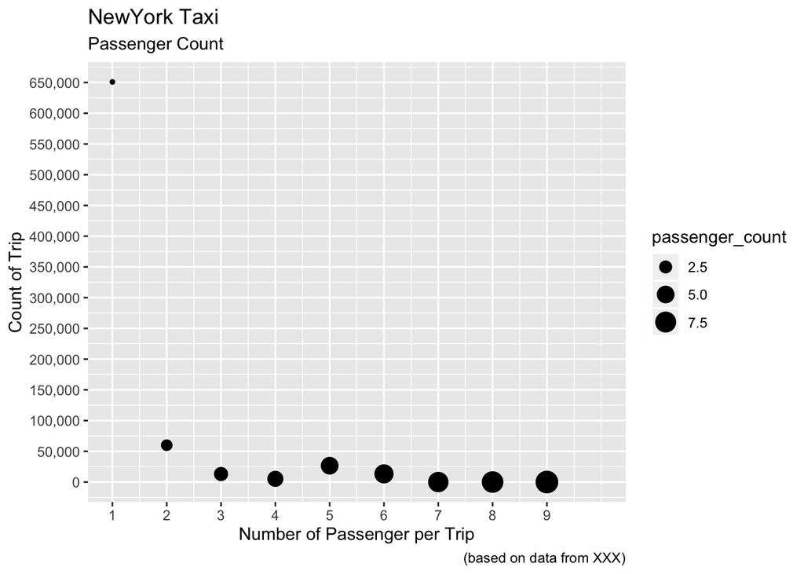

### Part 3.2: Distribution of Pick-Ups by Daytime.

- Distribution of Trips for Pick Up Time shows that midday and night is the rush time intervals for picking up a taxi in New York.

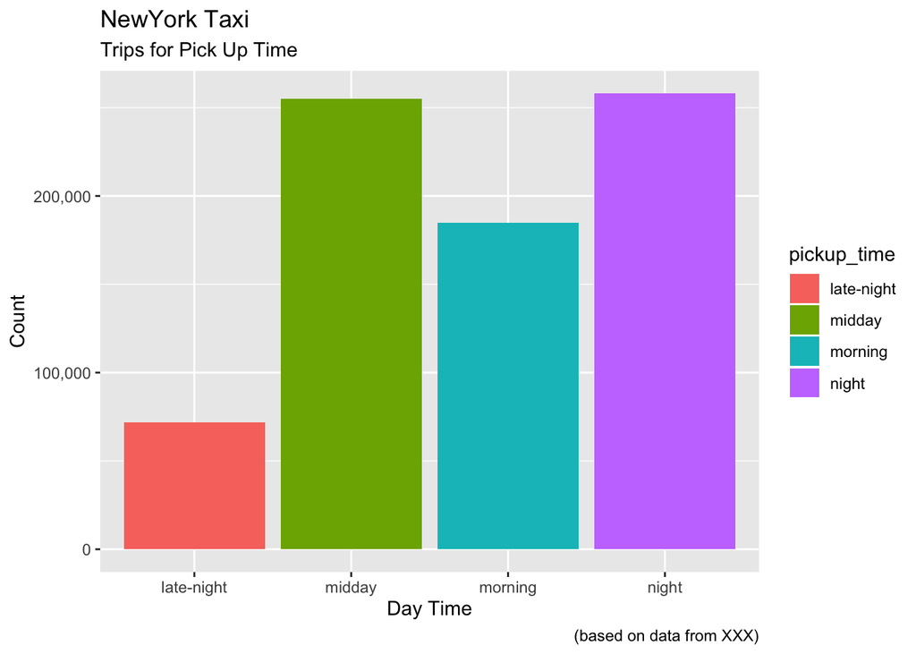

### Part 3.3: Distribution of Drop-offs by Daytime.

- Distribution of Trips for Drop Off Time shows that midday and night is parallelly to the Pick up Time and the rush time intervals are midday and night time intervals.

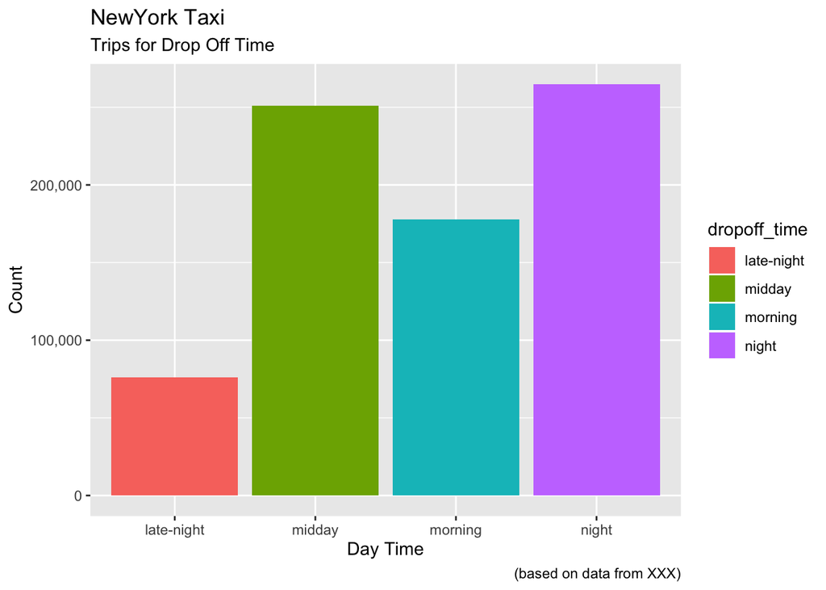

### Part 3.4: Total Trip Distance by Daytime

- Total distance of taxi trips from a month (2018.02) shows that midday is the highest total distance usage time interval in all. When we consider previous plots it is expected result for total distance of taxi trips by day time intervals.As we mentioned midday and night have greatest pick up and drop off counts as “rush” time intervals.

-At this point we wonder,what the average trip distance distribution of day time is and there is any charactersitics relationship between day time and average distance of taxi trips.

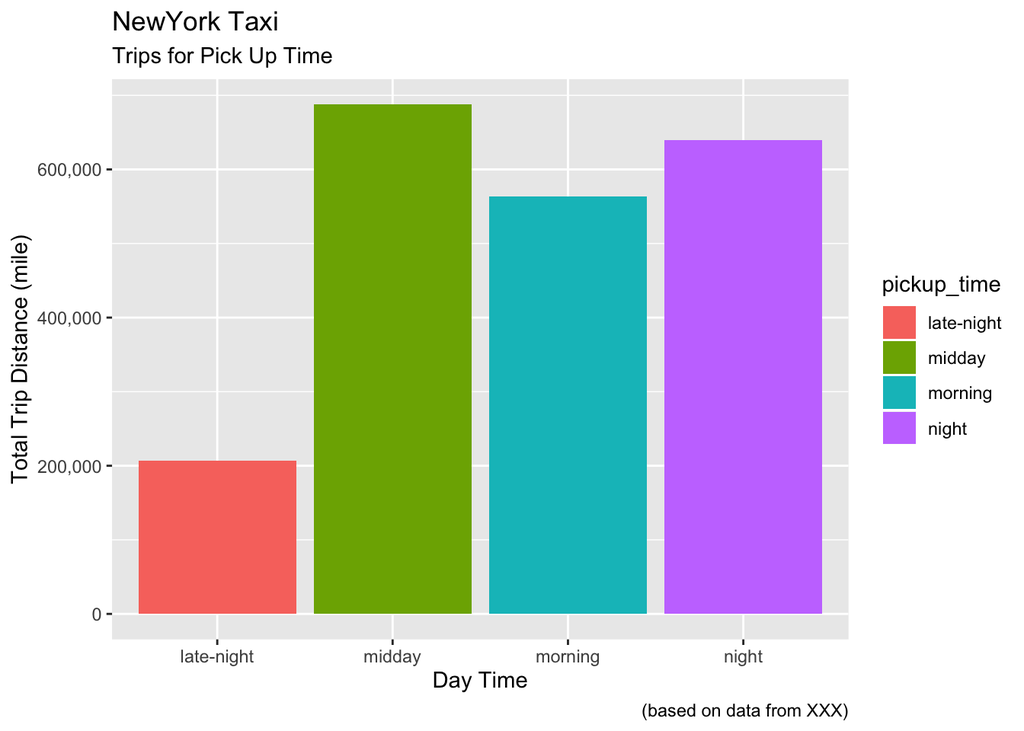

```r
#categorize trips according to pickup time.
pickup_distance_df <- sqldf("SELECT count(VendorID)as total,round(sum(trip_distance),2) as TRIP_DIST_SUM,
  CASE
      WHEN lpep_pickup_hour between '00:00:00' and '05:00:00' then 'late-night'
      WHEN lpep_pickup_hour between '05:00:01' and '12:00:00' then 'morning'
      WHEN lpep_pickup_hour between '12:00:01' and '18:00:00' then 'midday'
      WHEN lpep_pickup_hour between '18:00:01' and '23:59:59' then 'night'
      ELSE 0
      END pickup_time
      FROM df2
      GROUP BY pickup_time")


plot4 <- ggplot(pickup_distance_df, aes(x=pickup_time,y=TRIP_DIST_SUM,fill=pickup_time)) +
  geom_bar(position="dodge", stat="identity") +
  scale_y_continuous(labels = comma)+
  labs(subtitle="Trips for Pick Up Time", title= "NewYork Taxi",
       caption="(based on data from XXX)", y="Total Trip Distance (mile)", x="Day Time")
plot4
```

### Part 3.5: Average Trip Distance by Daytime

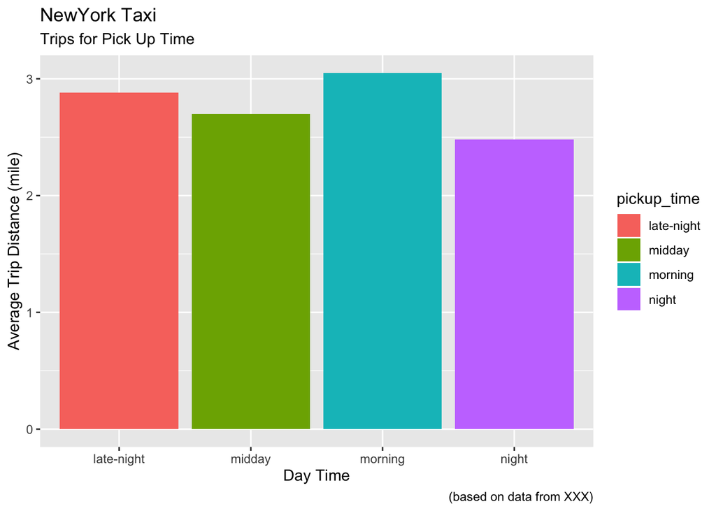

```r
#categorize trips according to pickup time.
pickup_distance_df2 <- sqldf("SELECT count(VendorID)as total,round(avg(trip_distance),2) as TRIP_DIST_AVG,
  CASE
      WHEN lpep_pickup_hour between '00:00:00' and '05:00:00' then 'late-night'
      WHEN lpep_pickup_hour between '05:00:01' and '12:00:00' then 'morning'
      WHEN lpep_pickup_hour between '12:00:01' and '18:00:00' then 'midday'
      WHEN lpep_pickup_hour between '18:00:01' and '23:59:59' then 'night'
      ELSE 0
      END pickup_time
      FROM df2
      GROUP BY pickup_time")


plot5 <- ggplot(pickup_distance_df2, aes(x=pickup_time,y=TRIP_DIST_AVG,fill=pickup_time)) +
  geom_bar(position="dodge", stat="identity") +
  scale_y_continuous(labels = comma)+
  labs(subtitle="Trips for Pick Up Time", title= "NewYork Taxi",
       caption="(based on data from XXX)", y="Average Trip Distance (mile)", x="Day Time")
plot5
```

## Conclusion

- After we parse “New York Taxi Data Set”, we decide to use only 1 month and try to analyze New Yorker’s taxi trips with different aspects.
- We made a close look of the group sizes of the taxi trips,we defined time intervals in terms of 4 scale as morning,midday,night and latenight.After we get distribution of pick up and drop off numbers versus time intervals, we determined rush times by time intervals.We also looks total and average distances per time interval to understand trips’ characteristics.
- For further topics one can divide day time to more frequent way and create a model to predict any month taxi usage as number or distance or any combinations of the details. Our scope and time ends here.

Have a great year ! ShineRs